# Identifying Fraud from Enron Email

### Introduction

In 2000, Enron was one of the largest companies in the United States. By 2002, it had collapsed into bankruptcy due to widespread corporate fraud. In the resulting Federal investigation, there was a significant amount of typically confidential information entered into public record, including tens of thousands of emails and detailed financial data for top executives.

This document attempts to explore and analys the dataset to gethring an information and handle missing/outlier on the dataset

Original dataset and starter's code can be downloaded from [this github repository](https://github.com/udacity/ud120-projects.git).

```python
import copy
import pickle
import pandas as pd
import numpy as np
import matplotlib.pyplot as plt
import seaborn as sns
%matplotlib inline
sns.set(style = "whitegrid", color_codes = True)
```

```python
#Load pickle data to dictionary
enron_data = pickle.load(open("final_project_dataset.pkl", "r") )
#Convert dictionary to pandas dataframe
df = pd.DataFrame.from_dict(enron_data, orient = 'index')
df = df.apply(pd.to_numeric, args = ('coerce',))
```

### Number of people in dataset?

```python
people = len(enron_data)
print "The dataset had " + str(people) + " people. "
```

```
The dataset had 146 people.
```

### Number of features in dataset

```python
features = len(enron_data['ALLEN PHILLIP K'])
print "The dataset had " + str(features) + " features."
```

```
The dataset had 21 features.
```

### Number of POI in dataset

```python
def poi_counter(file):
    count = 0
    for person in file:
        if file[person]['poi'] == True:
            count += 1
    print "The dataset had " + str(count) + " POI's"

poi_counter(enron_data)
```

```
The dataset had 18 POI's
```

```python
#First remove email_address feature from dataset and re-check
df.drop('email_address',
        inplace = True,
        axis = 1)
df.info()
```

```
<class 'pandas.core.frame.DataFrame'>
Index: 146 entries, ALLEN PHILLIP K to YEAP SOON
Data columns (total 20 columns):
salary                       95 non-null float64
to_messages                  86 non-null float64
deferral_payments            39 non-null float64
total_payments               125 non-null float64
exercised_stock_options      102 non-null float64
bonus                        82 non-null float64
restricted_stock             110 non-null float64
shared_receipt_with_poi      86 non-null float64
restricted_stock_deferred    18 non-null float64
total_stock_value            126 non-null float64
expenses                     95 non-null float64
loan_advances                4 non-null float64
from_messages                86 non-null float64
other                        93 non-null float64
from_this_person_to_poi      86 non-null float64
poi                          146 non-null bool
director_fees                17 non-null float64
deferred_income              49 non-null float64
long_term_incentive          66 non-null float64
from_poi_to_this_person      86 non-null float64
dtypes: bool(1), float64(19)
memory usage: 23.0+ KB
```

All data now are numeric value, except the 'email_address' feature that must be string, so I'll remove from the feature list.  
And from the report, can observe almost features contain missing value.  
Then next let's perform missing data handler.

### Identified type of features in the dataset

```python
#Creat the list fo features
poi_feature  = ['poi']

fin_features = ['salary',
                'deferral_payments',
                'total_payments',
                'loan_advances',
                'bonus',
                'restricted_stock_deferred',
                'deferred_income',
                'total_stock_value',
                'expenses',
                'exercised_stock_options',
                'other',
                'long_term_incentive',
                'restricted_stock',
                'director_fees']

email_features = ['to_messages',
                  'from_poi_to_this_person',
                  'from_messages',
                  'from_this_person_to_poi',
                  'shared_receipt_with_poi']
```

```python
all_feature = fin_features + email_features
```

```python
#List all of the person list
list(df.index)
```

```
['ALLEN PHILLIP K',
 'BADUM JAMES P',
 'BANNANTINE JAMES M',
 'BAXTER JOHN C',
 'BAY FRANKLIN R',
 'BAZELIDES PHILIP J',
 'BECK SALLY W',
 'BELDEN TIMOTHY N',
 'BELFER ROBERT',
 'BERBERIAN DAVID',
 'BERGSIEKER RICHARD P',
 'BHATNAGAR SANJAY',
 'BIBI PHILIPPE A',
 'BLACHMAN JEREMY M',
 'BLAKE JR. NORMAN P',
 'BOWEN JR RAYMOND M',
 'BROWN MICHAEL',
 'BUCHANAN HAROLD G',
 'BUTTS ROBERT H',
 'BUY RICHARD B',
 'CALGER CHRISTOPHER F',
 'CARTER REBECCA C',
 'CAUSEY RICHARD A',
 'CHAN RONNIE',
 'CHRISTODOULOU DIOMEDES',
 'CLINE KENNETH W',
 'COLWELL WESLEY',
 'CORDES WILLIAM R',
 'COX DAVID',
 'CUMBERLAND MICHAEL S',
 'DEFFNER JOSEPH M',
 'DELAINEY DAVID W',
 'DERRICK JR. JAMES V',
 'DETMERING TIMOTHY J',
 'DIETRICH JANET R',
 'DIMICHELE RICHARD G',
 'DODSON KEITH',
 'DONAHUE JR JEFFREY M',
 'DUNCAN JOHN H',
 'DURAN WILLIAM D',
```

[output cut: 91 more lines]

```
 'UMANOFF ADAM S',
 'URQUHART JOHN A',
 'WAKEHAM JOHN',
 'WALLS JR ROBERT H',
 'WALTERS GARETH W',
 'WASAFF GEORGE',
 'WESTFAHL RICHARD K',
 'WHALEY DAVID A',
 'WHALLEY LAWRENCE G',
 'WHITE JR THOMAS E',
 'WINOKUR JR. HERBERT S',
 'WODRASKA JOHN',
 'WROBEL BRUCE',
 'YEAGER F SCOTT',
 'YEAP SOON']
```

As know from the mini-project of the course, the entry that is the total of the financial features, therefore we should remove this entry 'TOTAL' entry from this analysis, also I found the entry 'THE TRAVEL AGENCY IN THE PARK' look seem ambiguous. I guess it may not name of person, dig more detail for this field.

```python
#View 'THE TRAVEL AGENCY IN THE PARK' info
df.loc["THE TRAVEL AGENCY IN THE PARK"]
```

```
salary                          NaN
to_messages                     NaN
deferral_payments               NaN
total_payments               362096
exercised_stock_options         NaN
bonus                           NaN
restricted_stock                NaN
shared_receipt_with_poi         NaN
restricted_stock_deferred       NaN
total_stock_value               NaN
expenses                        NaN
loan_advances                   NaN
from_messages                   NaN
other                        362096
from_this_person_to_poi         NaN
poi                           False
director_fees                   NaN
deferred_income                 NaN
long_term_incentive             NaN
from_poi_to_this_person         NaN
Name: THE TRAVEL AGENCY IN THE PARK, dtype: object
```

THE TRAVEL AGENCY IN THE PARK not in the poi, also most of values are NaN, then I'm determined as outlier record, so should remove from the dataset.  
Next try digging more for person who contain missing or outlier data.

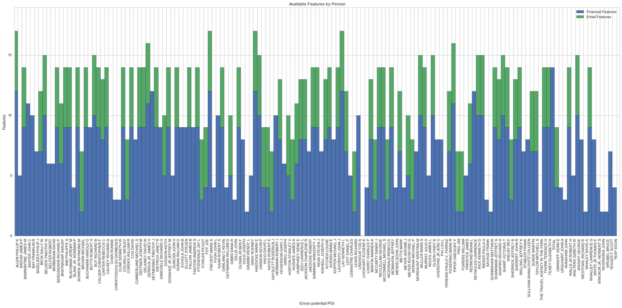

```python
#Make plot for each people on count of feature
plt.figure(figsize = (30,25))
ax = plt.subplot2grid((2,2),
                      (0,0),
                      colspan = 2)
person_df = pd.concat([df[fin_features].count(axis = 1),
                       df[email_features].count(axis = 1)],
                      keys = ["Financial Features","Email Features"]).unstack().T
person_df.plot(kind = 'bar', ax = ax, width = 1, stacked = True)

ax.set_ylim(0,len(fin_features + email_features))
ax.set_xlabel('Enron potential POI')
ax.set_ylabel('Features')
ax.set_title('Available Features by Person')
plt.savefig('financial_and_email_feature.png', bbox_inches='tight')
```

The plot show look seem 'LOCKHART EUGENE E' no existing feature, then let check detail for this record.

```python
#Check record of LOCKHART EUGENE E
df.loc['LOCKHART EUGENE E']
```

```
salary                         NaN
to_messages                    NaN
deferral_payments              NaN
total_payments                 NaN
exercised_stock_options        NaN
bonus                          NaN
restricted_stock               NaN
shared_receipt_with_poi        NaN
restricted_stock_deferred      NaN
total_stock_value              NaN
expenses                       NaN
loan_advances                  NaN
from_messages                  NaN
other                          NaN
from_this_person_to_poi        NaN
poi                          False
director_fees                  NaN
deferred_income                NaN
long_term_incentive            NaN
from_poi_to_this_person        NaN
Name: LOCKHART EUGENE E, dtype: object
```

All feature for 'LOCKHART EUGENE E, contain NaN values except poi, then should remove from the dataset.

Finally the dataset should remove following field  
remove 3 record 'TOTAL', 'THE TRAVEL AGENCY IN THE PARK', 'LOCKHART EUGENE E'  
Next perform to determind the missing/outlier of feature list.

```python
#Quick look at basic statistic summary
df.describe()
```

|  | salary | to_messages | deferral_payments | total_payments | exercised_stock_options | bonus | restricted_stock | shared_receipt_with_poi | restricted_stock_deferred | total_stock_value | expenses | loan_advances | from_messages | other | from_this_person_to_poi | poi | director_fees | deferred_income | long_term_incentive | from_poi_to_this_person |
| --- | --- | --- | --- | --- | --- | --- | --- | --- | --- | --- | --- | --- | --- | --- | --- | --- | --- | --- | --- | --- |
| count | 95.000000 | 86.000000 | 39.000000 | 1.250000e+02 | 1.020000e+02 | 82.000000 | 1.100000e+02 | 86.000000 | 18.000000 | 1.260000e+02 | 95.000000 | 4.0000 | 86.000000 | 93.000000 | 86.000000 | 146 | 17.000000 | 49.000000 | 66.000000 | 86.000000 |
| mean | 562194.294737 | 2073.860465 | 1642674.153846 | 5.081526e+06 | 5.987054e+06 | 2374234.609756 | 2.321741e+06 | 1176.465116 | 166410.555556 | 6.773957e+06 | 108728.915789 | 41962500.0000 | 608.790698 | 919064.967742 | 41.232558 | 0.123288 | 166804.882353 | -1140475.142857 | 1470361.454545 | 64.895349 |
| std | 2716369.154553 | 2582.700981 | 5161929.973575 | 2.906172e+07 | 3.106201e+07 | 10713327.969046 | 1.251828e+07 | 1178.317641 | 4201494.314703 | 3.895777e+07 | 533534.814109 | 47083208.7019 | 1841.033949 | 4589252.907638 | 100.073111 | 0.329899 | 319891.409747 | 4025406.378506 | 5942759.315498 | 86.979244 |
| min | 477.000000 | 57.000000 | -102500.000000 | 1.480000e+02 | 3.285000e+03 | 70000.000000 | -2.604490e+06 | 2.000000 | -7576788.000000 | -4.409300e+04 | 148.000000 | 400000.0000 | 12.000000 | 2.000000 | 0.000000 | False | 3285.000000 | -27992891.000000 | 69223.000000 | 0.000000 |
| 25% | 211816.000000 | 541.250000 | 81573.000000 | 3.944750e+05 | 5.278862e+05 | 431250.000000 | 2.540180e+05 | 249.750000 | -389621.750000 | 4.945102e+05 | 22614.000000 | 1600000.0000 | 22.750000 | 1215.000000 | 1.000000 | 0 | 98784.000000 | -694862.000000 | 281250.000000 | 10.000000 |
| 50% | 259996.000000 | 1211.000000 | 227449.000000 | 1.101393e+06 | 1.310814e+06 | 769375.000000 | 4.517400e+05 | 740.500000 | -146975.000000 | 1.102872e+06 | 46950.000000 | 41762500.0000 | 41.000000 | 52382.000000 | 8.000000 | 0 | 108579.000000 | -159792.000000 | 442035.000000 | 35.000000 |
| 75% | 312117.000000 | 2634.750000 | 1002671.500000 | 2.093263e+06 | 2.547724e+06 | 1200000.000000 | 1.002370e+06 | 1888.250000 | -75009.750000 | 2.949847e+06 | 79952.500000 | 82125000.0000 | 145.500000 | 362096.000000 | 24.750000 | 0 | 113784.000000 | -38346.000000 | 938672.000000 | 72.250000 |
| max | 26704229.000000 | 15149.000000 | 32083396.000000 | 3.098866e+08 | 3.117640e+08 | 97343619.000000 | 1.303223e+08 | 5521.000000 | 15456290.000000 | 4.345095e+08 | 5235198.000000 | 83925000.0000 | 14368.000000 | 42667589.000000 | 609.000000 | True | 1398517.000000 | -833.000000 | 48521928.000000 | 528.000000 |

```
salary                       65.0685
to_messages                  58.9041
deferral_payments            26.7123
total_payments               85.6164
exercised_stock_options       69.863
bonus                        56.1644
restricted_stock             75.3425
shared_receipt_with_poi      58.9041
restricted_stock_deferred    12.3288
total_stock_value            86.3014
expenses                     65.0685
loan_advances                2.73973
from_messages                58.9041
other                        63.6986
from_this_person_to_poi      58.9041
poi                              100
director_fees                11.6438
deferred_income              33.5616
long_term_incentive          45.2055
from_poi_to_this_person      58.9041
Name: count, dtype: object
```

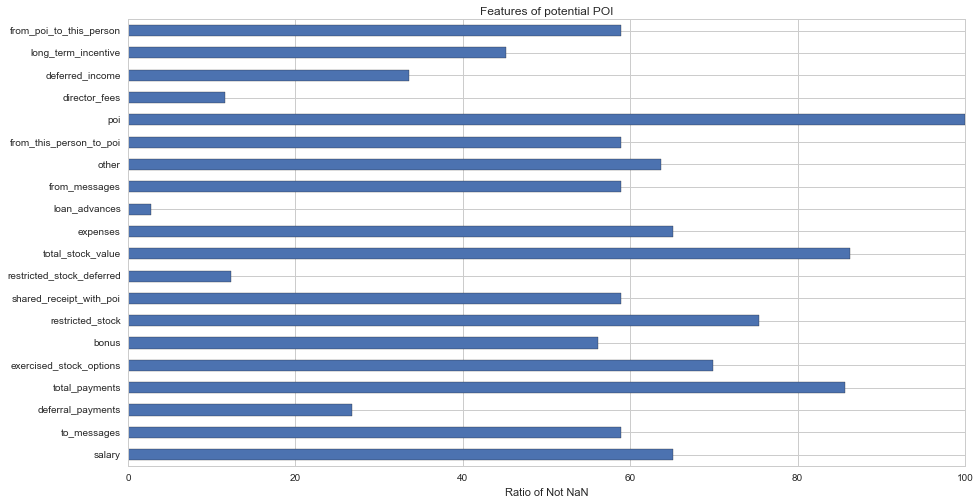

```python
#View ratio of missing
df_ratio = (df.describe().transpose()['count']/df.shape[0])*100
print df_ratio

#Plot count of not NaN in each feature
plt.figure(figsize = (15,8))
ax1 = plt.subplot2grid((1,1), (0,0))
df_ratio.plot(kind = 'barh', ax = ax1)
ax1.set_title('Features of potential POI')
ax1.set_xlabel('Ratio of Not NaN')
plt.savefig('Features_of_Not_NaN.png', bbox_inches='tight')
```

The result shows all 'loan_advances', 'director_fees', 'restricted_stock_deferred', 'deferral_payments' and 'deferred_income' contain lowest not NaN value.  
Next I'll check for feature that represent 'poi' as True.

```
salary                       94.4444
to_messages                  77.7778
deferral_payments            27.7778
total_payments                   100
exercised_stock_options      66.6667
bonus                        88.8889
restricted_stock             94.4444
shared_receipt_with_poi      77.7778
restricted_stock_deferred          0
total_stock_value                100
expenses                         100
loan_advances                5.55556
from_messages                77.7778
other                            100
from_this_person_to_poi      77.7778
poi                              100
director_fees                      0
deferred_income              61.1111
long_term_incentive          66.6667
from_poi_to_this_person      77.7778
Name: count, dtype: object
```

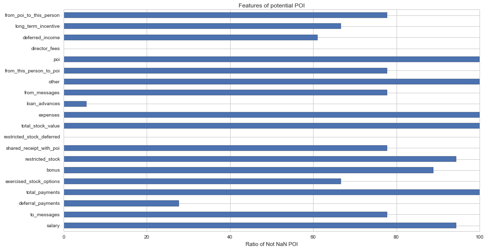

```python
#Not NaN features when POI is True
df_ppoi = df[df.poi == True]
df_ppoi_ratio = (df_ppoi.describe().transpose()['count']/df_ppoi.shape[0])*100
print df_ppoi_ratio

#Plot count of not NaN in each feature
plt.figure(figsize = (15,8))
ax1 = plt.subplot2grid((1,1), (0,0))
df_ppoi_ratio.plot(kind = 'barh', ax = ax1)
ax1.set_title('Features of potential POI')
ax1.set_xlabel('Ratio of Not NaN POI')
plt.savefig('Features_of_POI_Not_NaN.png', bbox_inches='tight')
```

From result, the 'restricted_stock_deferred' and 'director_fees' features not in 'poi', so we should remove these features from dataset.  
And 'loan_advances' had only one 'poi', then check more detail for this feature.

```
FREVERT MARK A      False
LAY KENNETH L        True
PICKERING MARK R    False
TOTAL               False
Name: poi, dtype: bool
```

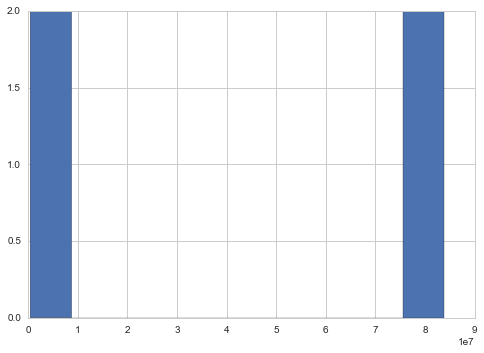

```python
#plot and check who had exist loan_advances
df['loan_advances'].hist()
df.loc[df['loan_advances']>0,'poi']
```

From result, the 'loan_advances' features had three person exist with only one person who is poi so I treate it outlier and should remove from feature list. And 'loan_advances' had only one 'poi', then check more detail for this feature.

```python
df.info()
```

```
<class 'pandas.core.frame.DataFrame'>
Index: 146 entries, ALLEN PHILLIP K to YEAP SOON
Data columns (total 20 columns):
salary                       95 non-null float64
to_messages                  86 non-null float64
deferral_payments            39 non-null float64
total_payments               125 non-null float64
exercised_stock_options      102 non-null float64
bonus                        82 non-null float64
restricted_stock             110 non-null float64
shared_receipt_with_poi      86 non-null float64
restricted_stock_deferred    18 non-null float64
total_stock_value            126 non-null float64
expenses                     95 non-null float64
loan_advances                4 non-null float64
from_messages                86 non-null float64
other                        93 non-null float64
from_this_person_to_poi      86 non-null float64
poi                          146 non-null bool
director_fees                17 non-null float64
deferred_income              49 non-null float64
long_term_incentive          66 non-null float64
from_poi_to_this_person      86 non-null float64
dtypes: bool(1), float64(19)
memory usage: 23.0+ KB
```

Finally we got 3 feature list 'loan_advances','director_fees', 'restricted_stock_deferred' that determined as outlier and should remove from datatset

### Missing/outlier handler

```python
#List of remove item
dropped_col_list = ['restricted_stock_deferred', 'director_fees', 'loan_advances']
dropped_row_list = ['TOTAL', 'THE TRAVEL AGENCY IN THE PARK', 'LOCKHART EUGENE E']
```

```python
#Update new list of financial features
fin_features = [i for i in fin_features if i not in dropped_col_list]
```

### Add New Features

```python
### Custom aggregate features
# from_poi_to_this_person_ratio: representing the ratio of messages were from a poi divide by all the messages.
# from_this_person_to_poi_ratio: representing the ratio of messages were to a poi divide by all the messages
# all_poi_ratio                : representing the extent of interactions of a poi and a person divide by all the messages
# total_earnings               : representing the sum of total_payment and total_stock

df['net_earnings'] = df['total_payments'] + df['total_stock_value']
df['poi_sending_ratio'] = df['from_poi_to_this_person'] / df['to_messages']
df['poi_receive_ratio'] = df['from_this_person_to_poi'] / df['from_messages']
df['poi_overall_ratio'] = df['poi_sending_ratio']  + df['poi_receive_ratio']
df['shared_receipt_ratio'] = df['shared_receipt_with_poi'] /(df['to_messages'] + df['from_messages'])
```

```python
#Update feature list
additional_fin_features  = ['net_earnings']
additional_email_features = ['poi_sending_ratio',
                             'poi_receive_ratio',
                             'poi_overall_ratio',
                             'shared_receipt_ratio']

#shared_receipt_with_poi
```

```python
#Add new feature to list
fin_features.extend(additional_fin_features)
email_features.extend(additional_email_features)
```

### Remove and Update Data

```python
# remove outlier and missing data
df = df.drop(dropped_row_list)
#update new dataset
df = df.drop(dropped_col_list, axis = 1)
#Re-Check
df.info()
```

```
<class 'pandas.core.frame.DataFrame'>
Index: 143 entries, ALLEN PHILLIP K to YEAP SOON
Data columns (total 22 columns):
salary                     94 non-null float64
to_messages                86 non-null float64
deferral_payments          38 non-null float64
total_payments             123 non-null float64
exercised_stock_options    101 non-null float64
bonus                      81 non-null float64
restricted_stock           109 non-null float64
shared_receipt_with_poi    86 non-null float64
total_stock_value          125 non-null float64
expenses                   94 non-null float64
from_messages              86 non-null float64
other                      91 non-null float64
from_this_person_to_poi    86 non-null float64
poi                        143 non-null bool
deferred_income            48 non-null float64
long_term_incentive        65 non-null float64
from_poi_to_this_person    86 non-null float64
net_earnings               107 non-null float64
poi_sending_ratio          86 non-null float64
poi_receive_ratio          86 non-null float64
poi_overall_ratio          86 non-null float64
shared_receipt_ratio       86 non-null float64
dtypes: bool(1), float64(21)
memory usage: 24.7+ KB
```

```python
#Fill in NaN values using mean values
df = df.fillna(df.median())
```

### Correlation Check

```python
def corrCheck(df,size = 8):
    '''Function plots a graphical correlation matrix for each pair of columns in the dataframe.

    Input:
        df: pandas DataFrame
        size: vertical and horizontal size of the plot'''

    corr = df.corr()
    fig, ax = plt.subplots(figsize=(size, size))
    #ax.matshow(corr)
    im = ax.imshow(corr, vmin=0, vmax=1)

    plt.xticks(range(len(corr.columns)), corr.columns, rotation='vertical');
    plt.yticks(range(len(corr.columns)), corr.columns);

    # Make an axis for the colorbar on the right side
    cax = fig.add_axes([1, 0.12, 0.04, 0.78])
    fig.colorbar(im, cax=cax)

    return corr
```

|  | salary | deferral_payments | total_payments | bonus | deferred_income | total_stock_value | expenses | exercised_stock_options | other | long_term_incentive | restricted_stock | net_earnings |
| --- | --- | --- | --- | --- | --- | --- | --- | --- | --- | --- | --- | --- |
| salary | 1.000000 | 0.283343 | 0.576968 | 0.521736 | -0.272968 | 0.559071 | 0.136303 | 0.503816 | 0.588600 | 0.478304 | 0.523170 | 0.625420 |
| deferral_payments | 0.283343 | 1.000000 | 0.122297 | 0.180168 | -0.554559 | 0.103224 | -0.024373 | 0.085584 | 0.364841 | 0.099930 | 0.087074 | 0.122697 |
| total_payments | 0.576968 | 0.122297 | 1.000000 | 0.571891 | -0.090181 | 0.661096 | 0.115970 | 0.598652 | 0.828698 | 0.530526 | 0.601717 | 0.934258 |
| bonus | 0.521736 | 0.180168 | 0.571891 | 1.000000 | -0.288690 | 0.465863 | 0.071094 | 0.428998 | 0.381018 | 0.448479 | 0.390873 | 0.578281 |
| deferred_income | -0.272968 | -0.554559 | -0.090181 | -0.288690 | 1.000000 | -0.245841 | 0.050135 | -0.264628 | -0.254452 | -0.255412 | -0.113870 | -0.165111 |
| total_stock_value | 0.559071 | 0.103224 | 0.661096 | 0.465863 | -0.245841 | 1.000000 | 0.054299 | 0.960449 | 0.633160 | 0.424350 | 0.779699 | 0.874421 |
| expenses | 0.136303 | -0.024373 | 0.115970 | 0.071094 | 0.050135 | 0.054299 | 1.000000 | 0.036126 | 0.084900 | -0.029913 | 0.075449 | 0.098086 |
| exercised_stock_options | 0.503816 | 0.085584 | 0.598652 | 0.428998 | -0.264628 | 0.960449 | 0.036126 | 1.000000 | 0.550188 | 0.401840 | 0.588231 | 0.814675 |
| other | 0.588600 | 0.364841 | 0.828698 | 0.381018 | -0.254452 | 0.633160 | 0.084900 | 0.550188 | 1.000000 | 0.541107 | 0.636303 | 0.821432 |
| long_term_incentive | 0.478304 | 0.099930 | 0.530526 | 0.448479 | -0.255412 | 0.424350 | -0.029913 | 0.401840 | 0.541107 | 1.000000 | 0.346226 | 0.532746 |
| restricted_stock | 0.523170 | 0.087074 | 0.601717 | 0.390873 | -0.113870 | 0.779699 | 0.075449 | 0.588231 | 0.636303 | 0.346226 | 1.000000 | 0.749202 |
| net_earnings | 0.625420 | 0.122697 | 0.934258 | 0.578281 | -0.165111 | 0.874421 | 0.098086 | 0.814675 | 0.821432 | 0.532746 | 0.749202 | 1.000000 |

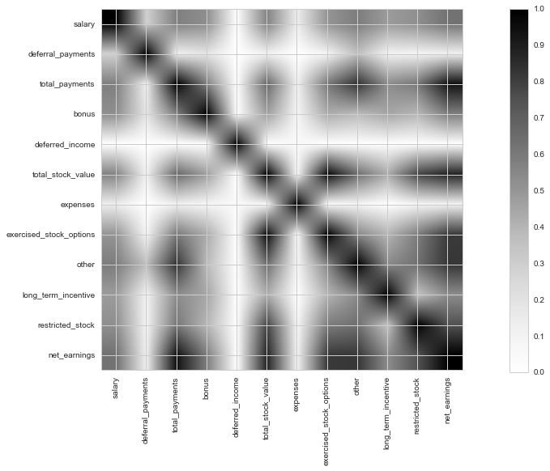

```python
corrCheck(df[fin_features])
```

### Conclusion

3 features that determined as outlier and should remove from datatset were: 'loan_advances' 'director_fees' 'restricted_stock_deferred'

3 record that determined as outlier and should remove from datatset were: 'TOTAL', 'THE TRAVEL AGENCY IN THE PARK', 'LOCKHART EUGENE E'

Finally dataset contain 143 with 22 feature.